# Case Study 01 Write Up

Brandon Lawrence

November 6, 2016

## Introduction

This case involved exploring the relationship between GDP and Income Group as defined by the World Bank.

Source Code and Analysis can be found in the GitHub Repository at the following link:

https://github.com/blawrenceDS/CaseStudy01

Data Sources:

http://data.worldbank.org/data-catalog/GDP-ranking-table

http://data.worldbank.org/data-catalog/ed-stats

## Methods

The analysis began by downloading the required datasets from the World Bank database. The data was then cleaned for formatting and to distill the germane information. Then the datasets were merged together to create a table that listed country by GDP rank, GDP nominal amount, and income group.

## Results

We wanted to observe which country had the 13th lowest GDP in the study.

```r
#Choose the ranking (lowest = 1) for which you would like to find the country
rank <- 13

#Sort the GDP ranks appropriately
DataSortbyGDP <- arrange(GDP_EDU_data,desc(as.numeric(GDP_Rank)))

#Extracts country name from data frame
Country_GDP_Rank <- as.vector(DataSortbyGDP[[rank,4]])

#Output country name to console
Country_GDP_Rank
```

```
## [1] "St. Kitts and Nevis"
```

The average GDP ranking of high income OECD countries was 33 and 92 was the average ranking for high income non OECD countries.

```r
#Find the average ranking of each income group


Income_Group_Avg_Ranks <- setNames(aggregate(GDP_EDU_data$GDP_Rank,
                                             by = list(GDP_EDU_data$`Income Group`),
                                             mean),c("Income Group","Average Rank"))

Income_Group_Avg_Ranks$`Average Rank` <- round(Income_Group_Avg_Ranks$`Average Rank`, 0)
Income_Group_Avg_Ranks
```

```
##           Income Group Average Rank
## 1 High income: nonOECD           92
## 2    High income: OECD           33
## 3           Low income          134
## 4  Lower middle income          108
## 5  Upper middle income           92
```

In general, a higher income group portends a higher GDP, though the spread is quite large (note the log scale).

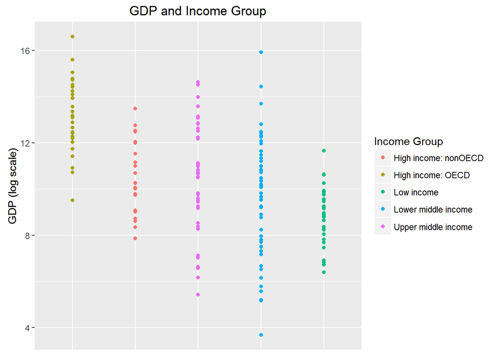

5 countries are lower middle income, but in the top 38 by GDP.

```
##                    Var1 Var2 Freq
## 1  High income: nonOECD    1    4
## 2     High income: OECD    1   18
## 3            Low income    1    0
## 4   Lower middle income    1    5
## 5   Upper middle income    1   11
## 6  High income: nonOECD    2    5
## 7     High income: OECD    2   10
## 8            Low income    2    1
## 9   Lower middle income    2   13
## 10  Upper middle income    2    9
## 11 High income: nonOECD    3    8
## 12    High income: OECD    3    1
## 13           Low income    3    9
## 14  Lower middle income    3   11
## 15  Upper middle income    3    8
## 16 High income: nonOECD    4    4
## 17    High income: OECD    4    1
## 18           Low income    4   16
## 19  Lower middle income    4    9
## 20  Upper middle income    4    8
## 21 High income: nonOECD    5    2
## 22    High income: OECD    5    0
## 23           Low income    5   11
## 24  Lower middle income    5   16
## 25  Upper middle income    5    9
```

## Conclusion

GDP is positively correlated with income, though notable exceptions exist, especially in countries such as Russia and Malaysia where GDP is boosted by natural resource extraction but may not result in higher income for the average citizen. China (#2) and India (#10) also stand out as lower income countries in the top ten GDP rankings, though population size is most likely the driving variable in both cases. The United States is far and away an outlier with a GDP that is double of #2 China. What is interesting as well is that of high income countries, only OECD countries break into the top 10 with the petro state Saudia Arabia (#19) being the first high income Non OECD country in the list.